# Step AIC

Alan T. Arnholt

9/16/2019

## R Markdown

```r
library(MASS)
names(Boston)
```

```
##  [1] "crim"    "zn"      "indus"   "chas"    "nox"     "rm"      "age"
##  [8] "dis"     "rad"     "tax"     "ptratio" "black"   "lstat"   "medv"
```

```r
cor(Boston)
```

```
##                crim          zn       indus         chas         nox
## crim     1.00000000 -0.20046922  0.40658341 -0.055891582  0.42097171
## zn      -0.20046922  1.00000000 -0.53382819 -0.042696719 -0.51660371
## indus    0.40658341 -0.53382819  1.00000000  0.062938027  0.76365145
## chas    -0.05589158 -0.04269672  0.06293803  1.000000000  0.09120281
## nox      0.42097171 -0.51660371  0.76365145  0.091202807  1.00000000
## rm      -0.21924670  0.31199059 -0.39167585  0.091251225 -0.30218819
## age      0.35273425 -0.56953734  0.64477851  0.086517774  0.73147010
## dis     -0.37967009  0.66440822 -0.70802699 -0.099175780 -0.76923011
## rad      0.62550515 -0.31194783  0.59512927 -0.007368241  0.61144056
## tax      0.58276431 -0.31456332  0.72076018 -0.035586518  0.66802320
## ptratio  0.28994558 -0.39167855  0.38324756 -0.121515174  0.18893268
## black   -0.38506394  0.17552032 -0.35697654  0.048788485 -0.38005064
## lstat    0.45562148 -0.41299457  0.60379972 -0.053929298  0.59087892
## medv    -0.38830461  0.36044534 -0.48372516  0.175260177 -0.42732077
##                  rm         age         dis          rad         tax
## crim    -0.21924670  0.35273425 -0.37967009  0.625505145  0.58276431
## zn       0.31199059 -0.56953734  0.66440822 -0.311947826 -0.31456332
## indus   -0.39167585  0.64477851 -0.70802699  0.595129275  0.72076018
## chas     0.09125123  0.08651777 -0.09917578 -0.007368241 -0.03558652
## nox     -0.30218819  0.73147010 -0.76923011  0.611440563  0.66802320
## rm       1.00000000 -0.24026493  0.20524621 -0.209846668 -0.29204783
## age     -0.24026493  1.00000000 -0.74788054  0.456022452  0.50645559
## dis      0.20524621 -0.74788054  1.00000000 -0.494587930 -0.53443158
## rad     -0.20984667  0.45602245 -0.49458793  1.000000000  0.91022819
## tax     -0.29204783  0.50645559 -0.53443158  0.910228189  1.00000000
## ptratio -0.35550149  0.26151501 -0.23247054  0.464741179  0.46085304
## black    0.12806864 -0.27353398  0.29151167 -0.444412816 -0.44180801
## lstat   -0.61380827  0.60233853 -0.49699583  0.488676335  0.54399341
## medv     0.69535995 -0.37695457  0.24992873 -0.381626231 -0.46853593
##            ptratio       black      lstat       medv
## crim     0.2899456 -0.38506394  0.4556215 -0.3883046
## zn      -0.3916785  0.17552032 -0.4129946  0.3604453
## indus    0.3832476 -0.35697654  0.6037997 -0.4837252
## chas    -0.1215152  0.04878848 -0.0539293  0.1752602
## nox      0.1889327 -0.38005064  0.5908789 -0.4273208
## rm      -0.3555015  0.12806864 -0.6138083  0.6953599
## age      0.2615150 -0.27353398  0.6023385 -0.3769546
## dis     -0.2324705  0.29151167 -0.4969958  0.2499287
## rad      0.4647412 -0.44441282  0.4886763 -0.3816262
## tax      0.4608530 -0.44180801  0.5439934 -0.4685359
## ptratio  1.0000000 -0.17738330  0.3740443 -0.5077867
## black   -0.1773833  1.00000000 -0.3660869  0.3334608
## lstat    0.3740443 -0.36608690  1.0000000 -0.7376627
## medv    -0.5077867  0.33346082 -0.7376627  1.0000000
```

```r
stepAIC(lm(medv ~ 1, data = Boston), scope = (~crim+zn + indus + chas + nox + rm + age +dis + rad + tax + ptratio + black +lstat), direction = "forward", test = "F")
```

```
## Start:  AIC=2246.51
## medv ~ 1
##
##           Df Sum of Sq   RSS    AIC F Value     Pr(F)
## + lstat    1   23243.9 19472 1851.0  601.62 < 2.2e-16 ***
## + rm       1   20654.4 22062 1914.2  471.85 < 2.2e-16 ***
## + ptratio  1   11014.3 31702 2097.6  175.11 < 2.2e-16 ***
## + indus    1    9995.2 32721 2113.6  153.95 < 2.2e-16 ***
## + tax      1    9377.3 33339 2123.1  141.76 < 2.2e-16 ***
## + nox      1    7800.1 34916 2146.5  112.59 < 2.2e-16 ***
## + crim     1    6440.8 36276 2165.8   89.49 < 2.2e-16 ***
## + rad      1    6221.1 36495 2168.9   85.91 < 2.2e-16 ***
## + age      1    6069.8 36647 2171.0   83.48 < 2.2e-16 ***
## + zn       1    5549.7 37167 2178.1   75.26 < 2.2e-16 ***
## + black    1    4749.9 37966 2188.9   63.05 1.318e-14 ***
## + dis      1    2668.2 40048 2215.9   33.58 1.207e-08 ***
## + chas     1    1312.1 41404 2232.7   15.97 7.391e-05 ***
## <none>                 42716 2246.5
## ---
## Signif. codes:  0 '***' 0.001 '**' 0.01 '*' 0.05 '.' 0.1 ' ' 1
##
## Step:  AIC=1851.01
## medv ~ lstat
##
##           Df Sum of Sq   RSS    AIC F Value     Pr(F)
## + rm       1    4033.1 15439 1735.6 131.394 < 2.2e-16 ***
## + ptratio  1    2670.1 16802 1778.4  79.934 < 2.2e-16 ***
## + chas     1     786.3 18686 1832.2  21.167 5.336e-06 ***
## + dis      1     772.4 18700 1832.5  20.776 6.488e-06 ***
## + age      1     304.3 19168 1845.0   7.984  0.004907 **
## + tax      1     274.4 19198 1845.8   7.190  0.007574 **
## + black    1     198.3 19274 1847.8   5.176  0.023316 *
## + zn       1     160.3 19312 1848.8   4.176  0.041527 *
## + crim     1     146.9 19325 1849.2   3.825  0.051059 .
## + indus    1      98.7 19374 1850.4   2.564  0.109981
## <none>                 19472 1851.0
## + rad      1      25.1 19447 1852.4   0.649  0.420799
## + nox      1       4.8 19468 1852.9   0.124  0.724966
## ---
## Signif. codes:  0 '***' 0.001 '**' 0.01 '*' 0.05 '.' 0.1 ' ' 1
```

[output cut: 131 more lines]

```
## + tax    1   273.619 11081 1585.8 12.1978 0.0005214 ***
## <none>               11355 1596.1
## + indus  1    33.894 11321 1596.6  1.4790 0.2245162
## + age    1     0.096 11355 1598.1  0.0042 0.9485270
## ---
## Signif. codes:  0 '***' 0.001 '**' 0.01 '*' 0.05 '.' 0.1 ' ' 1
##
## Step:  AIC=1585.76
## medv ~ lstat + rm + ptratio + dis + nox + chas + black + zn +
##     crim + rad + tax
##
##         Df Sum of Sq   RSS    AIC F Value  Pr(F)
## <none>               11081 1585.8
## + indus  1   2.51754 11079 1587.7 0.11203 0.7380
## + age    1   0.06271 11081 1587.8 0.00279 0.9579
```

```
##
## Call:
## lm(formula = medv ~ lstat + rm + ptratio + dis + nox + chas +
##     black + zn + crim + rad + tax, data = Boston)
##
## Coefficients:
## (Intercept)        lstat           rm      ptratio          dis
##   36.341145    -0.522553     3.801579    -0.946525    -1.492711
##         nox         chas        black           zn         crim
##  -17.376023     2.718716     0.009291     0.045845    -0.108413
##         rad          tax
##    0.299608    -0.011778
```

```r
### OR
null <- lm(medv ~ 1, data = Boston)
full <- lm(medv ~ ., data = Boston)
stepAIC(null, scope = list(lower = null, upper = full), direction = "forward", test = "F")
```

```
## Start:  AIC=2246.51
## medv ~ 1
##
##           Df Sum of Sq   RSS    AIC F Value     Pr(F)
## + lstat    1   23243.9 19472 1851.0  601.62 < 2.2e-16 ***
## + rm       1   20654.4 22062 1914.2  471.85 < 2.2e-16 ***
## + ptratio  1   11014.3 31702 2097.6  175.11 < 2.2e-16 ***
## + indus    1    9995.2 32721 2113.6  153.95 < 2.2e-16 ***
## + tax      1    9377.3 33339 2123.1  141.76 < 2.2e-16 ***
## + nox      1    7800.1 34916 2146.5  112.59 < 2.2e-16 ***
## + crim     1    6440.8 36276 2165.8   89.49 < 2.2e-16 ***
## + rad      1    6221.1 36495 2168.9   85.91 < 2.2e-16 ***
## + age      1    6069.8 36647 2171.0   83.48 < 2.2e-16 ***
## + zn       1    5549.7 37167 2178.1   75.26 < 2.2e-16 ***
## + black    1    4749.9 37966 2188.9   63.05 1.318e-14 ***
## + dis      1    2668.2 40048 2215.9   33.58 1.207e-08 ***
## + chas     1    1312.1 41404 2232.7   15.97 7.391e-05 ***
## <none>                 42716 2246.5
## ---
## Signif. codes:  0 '***' 0.001 '**' 0.01 '*' 0.05 '.' 0.1 ' ' 1
##
## Step:  AIC=1851.01
## medv ~ lstat
##
##           Df Sum of Sq   RSS    AIC F Value     Pr(F)
## + rm       1    4033.1 15439 1735.6 131.394 < 2.2e-16 ***
## + ptratio  1    2670.1 16802 1778.4  79.934 < 2.2e-16 ***
## + chas     1     786.3 18686 1832.2  21.167 5.336e-06 ***
## + dis      1     772.4 18700 1832.5  20.776 6.488e-06 ***
## + age      1     304.3 19168 1845.0   7.984  0.004907 **
## + tax      1     274.4 19198 1845.8   7.190  0.007574 **
## + black    1     198.3 19274 1847.8   5.176  0.023316 *
## + zn       1     160.3 19312 1848.8   4.176  0.041527 *
## + crim     1     146.9 19325 1849.2   3.825  0.051059 .
## + indus    1      98.7 19374 1850.4   2.564  0.109981
## <none>                 19472 1851.0
## + rad      1      25.1 19447 1852.4   0.649  0.420799
## + nox      1       4.8 19468 1852.9   0.124  0.724966
## ---
## Signif. codes:  0 '***' 0.001 '**' 0.01 '*' 0.05 '.' 0.1 ' ' 1
```

[output cut: 131 more lines]

```
## + tax    1   273.619 11081 1585.8 12.1978 0.0005214 ***
## <none>               11355 1596.1
## + indus  1    33.894 11321 1596.6  1.4790 0.2245162
## + age    1     0.096 11355 1598.1  0.0042 0.9485270
## ---
## Signif. codes:  0 '***' 0.001 '**' 0.01 '*' 0.05 '.' 0.1 ' ' 1
##
## Step:  AIC=1585.76
## medv ~ lstat + rm + ptratio + dis + nox + chas + black + zn +
##     crim + rad + tax
##
##         Df Sum of Sq   RSS    AIC F Value  Pr(F)
## <none>               11081 1585.8
## + indus  1   2.51754 11079 1587.7 0.11203 0.7380
## + age    1   0.06271 11081 1587.8 0.00279 0.9579
```

```
##
## Call:
## lm(formula = medv ~ lstat + rm + ptratio + dis + nox + chas +
##     black + zn + crim + rad + tax, data = Boston)
##
## Coefficients:
## (Intercept)        lstat           rm      ptratio          dis
##   36.341145    -0.522553     3.801579    -0.946525    -1.492711
##         nox         chas        black           zn         crim
##  -17.376023     2.718716     0.009291     0.045845    -0.108413
##         rad          tax
##    0.299608    -0.011778
```

```r
mod <- lm(medv ~ lstat + rm + ptratio + dis, data = Boston)
summary(mod)
```

```
##
## Call:
## lm(formula = medv ~ lstat + rm + ptratio + dis, data = Boston)
##
## Residuals:
##      Min       1Q   Median       3Q      Max
## -15.4172  -3.0971  -0.6397   1.8727  27.1088
##
## Coefficients:
##             Estimate Std. Error t value Pr(>|t|)
## (Intercept) 24.47136    4.07802   6.001 3.77e-09 ***
## lstat       -0.66544    0.04675 -14.233  < 2e-16 ***
## rm           4.22379    0.42382   9.966  < 2e-16 ***
## ptratio     -0.97365    0.11603  -8.391 4.94e-16 ***
## dis         -0.55193    0.12695  -4.348 1.67e-05 ***
## ---
## Signif. codes:  0 '***' 0.001 '**' 0.01 '*' 0.05 '.' 0.1 ' ' 1
##
## Residual standard error: 5.139 on 501 degrees of freedom
## Multiple R-squared:  0.6903, Adjusted R-squared:  0.6878
## F-statistic: 279.2 on 4 and 501 DF,  p-value: < 2.2e-16
```

```r
#
X <- model.matrix(mod)
XTXI <- solve(t(X)%*%X)
XTXI
```

```
##              (Intercept)         lstat            rm       ptratio
## (Intercept)  0.629814721 -3.517355e-03 -0.0555618418 -1.134444e-02
## lstat       -0.003517355  8.278010e-05  0.0004195174 -3.031815e-05
## rm          -0.055561842  4.195174e-04  0.0068025561  3.401768e-04
## ptratio     -0.011344438 -3.031815e-05  0.0003401768  5.098755e-04
## dis         -0.006529463  1.035451e-04  0.0003225101  4.746855e-05
##                       dis
## (Intercept) -6.529463e-03
## lstat        1.035451e-04
## rm           3.225101e-04
## ptratio      4.746855e-05
## dis          6.103714e-04
```

```r
# But best to get XTXI using cov.unscaled
XTXI <- summary(mod)$cov.unscaled
XTXI
```

```
##              (Intercept)         lstat            rm       ptratio
## (Intercept)  0.629814721 -3.517355e-03 -0.0555618418 -1.134444e-02
## lstat       -0.003517355  8.278010e-05  0.0004195174 -3.031815e-05
## rm          -0.055561842  4.195174e-04  0.0068025561  3.401768e-04
## ptratio     -0.011344438 -3.031815e-05  0.0003401768  5.098755e-04
## dis         -0.006529463  1.035451e-04  0.0003225101  4.746855e-05
##                       dis
## (Intercept) -6.529463e-03
## lstat        1.035451e-04
## rm           3.225101e-04
## ptratio      4.746855e-05
## dis          6.103714e-04
```

```r
betahat <- XTXI%*%t(X)%*%Boston$medv
betahat
```

```
##                   [,1]
## (Intercept) 24.4713576
## lstat       -0.6654360
## rm           4.2237922
## ptratio     -0.9736458
## dis         -0.5519263
```

```r
MSE <- summary(mod)$sigma^2
vcmat <- MSE*XTXI
vcmat
```

```
##             (Intercept)         lstat           rm       ptratio
## (Intercept) 16.63026109 -0.0928757902 -1.467110733 -0.2995499532
## lstat       -0.09287579  0.0021858089  0.011077358 -0.0008005508
## rm          -1.46711073  0.0110773585  0.179621530  0.0089823706
## ptratio     -0.29954995 -0.0008005508  0.008982371  0.0134632641
## dis         -0.17241051  0.0027341081  0.008515881  0.0012534074
##                      dis
## (Intercept) -0.172410512
## lstat        0.002734108
## rm           0.008515881
## ptratio      0.001253407
## dis          0.016116859
```

```r
se <- diag(vcmat)^.5
ts <- betahat/se
pvalues <- pt(abs(ts), 501, lower = FALSE)*2
pvalues
```

```
##                     [,1]
## (Intercept) 3.768552e-09
## lstat       7.535269e-39
## rm          1.829210e-21
## ptratio     4.941919e-16
## dis         1.668467e-05
```

```r
CI <- betahat[2] + c(-1, 1)*qt(.975, 501)*se[2]
CI
```

```
## [1] -0.7572914 -0.5735806
```

```r
confint(mod)
```

```
##                  2.5 %     97.5 %
## (Intercept) 16.4592263 32.4834890
## lstat       -0.7572914 -0.5735806
## rm           3.3911130  5.0564714
## ptratio     -1.2016137 -0.7456779
## dis         -0.8013506 -0.3025021
```

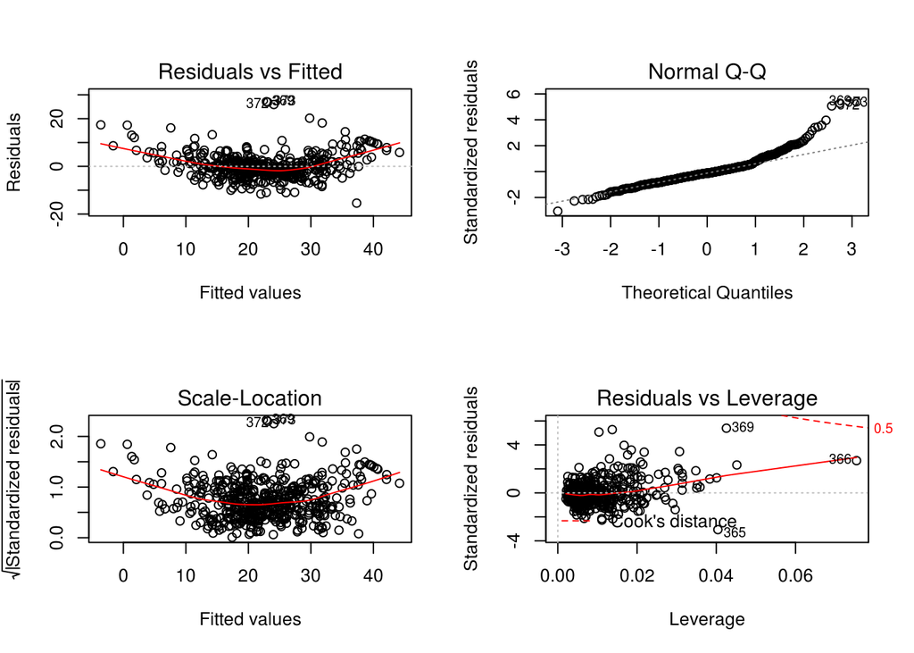

```r
par(mfrow = c(2, 2))
plot(mod)
```

```r
par(mfrow = c(1,1))
```

```r
mod2 <- lm(medv ~ . - age - indus, data = Boston)
summary(mod2)
```

```
##
## Call:
## lm(formula = medv ~ . - age - indus, data = Boston)
##
## Residuals:
##      Min       1Q   Median       3Q      Max
## -15.5984  -2.7386  -0.5046   1.7273  26.2373
##
## Coefficients:
##               Estimate Std. Error t value Pr(>|t|)
## (Intercept)  36.341145   5.067492   7.171 2.73e-12 ***
## crim         -0.108413   0.032779  -3.307 0.001010 **
## zn            0.045845   0.013523   3.390 0.000754 ***
## chas          2.718716   0.854240   3.183 0.001551 **
## nox         -17.376023   3.535243  -4.915 1.21e-06 ***
## rm            3.801579   0.406316   9.356  < 2e-16 ***
## dis          -1.492711   0.185731  -8.037 6.84e-15 ***
## rad           0.299608   0.063402   4.726 3.00e-06 ***
## tax          -0.011778   0.003372  -3.493 0.000521 ***
## ptratio      -0.946525   0.129066  -7.334 9.24e-13 ***
## black         0.009291   0.002674   3.475 0.000557 ***
## lstat        -0.522553   0.047424 -11.019  < 2e-16 ***
## ---
## Signif. codes:  0 '***' 0.001 '**' 0.01 '*' 0.05 '.' 0.1 ' ' 1
##
## Residual standard error: 4.736 on 494 degrees of freedom
## Multiple R-squared:  0.7406, Adjusted R-squared:  0.7348
## F-statistic: 128.2 on 11 and 494 DF,  p-value: < 2.2e-16
```

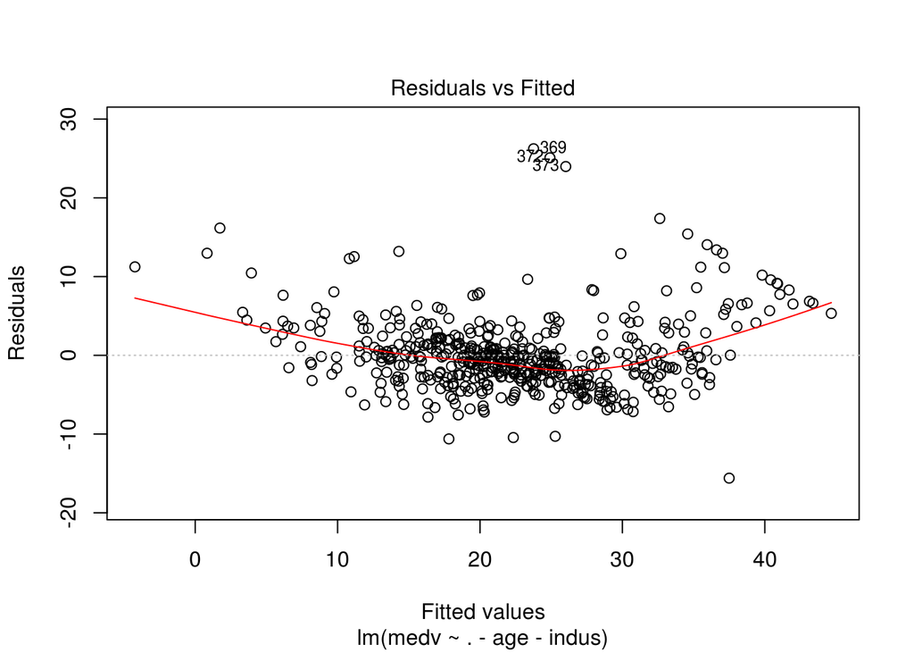

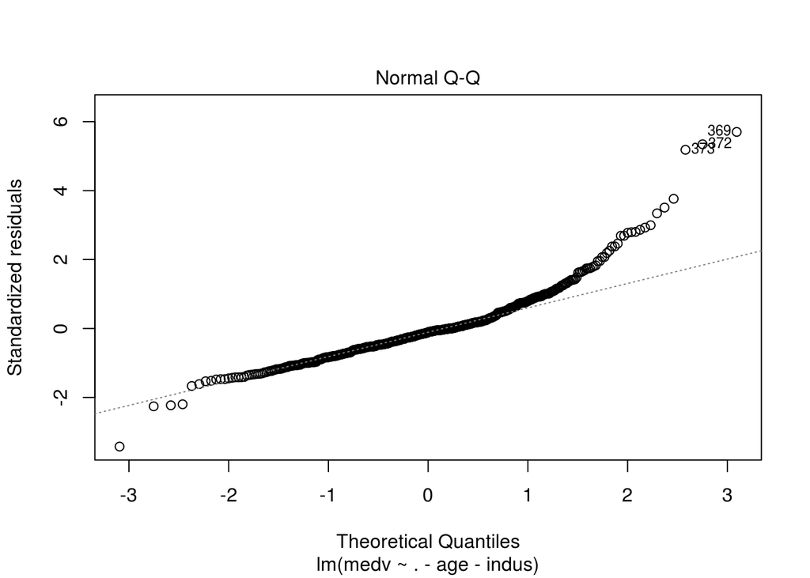

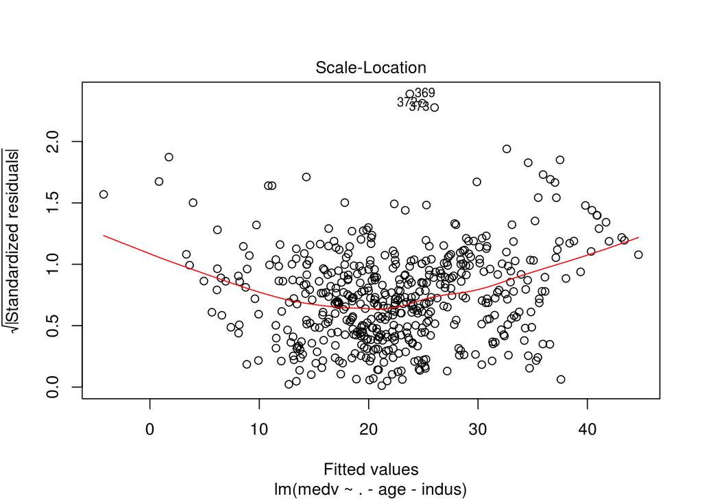

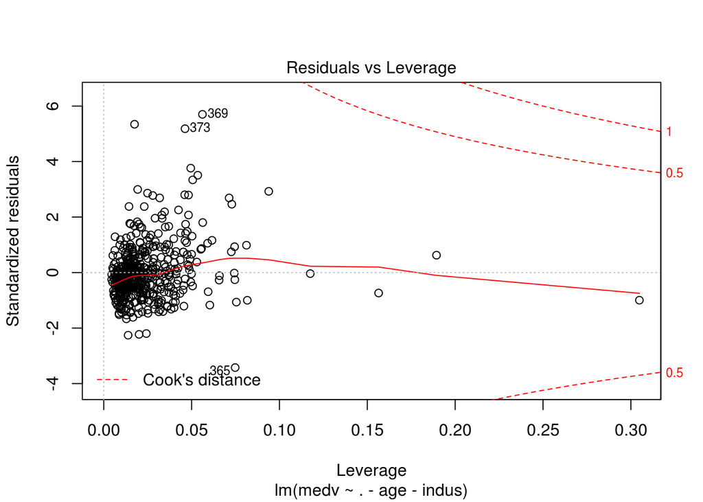

```r
plot(mod2)
```

```r
library(car)
```

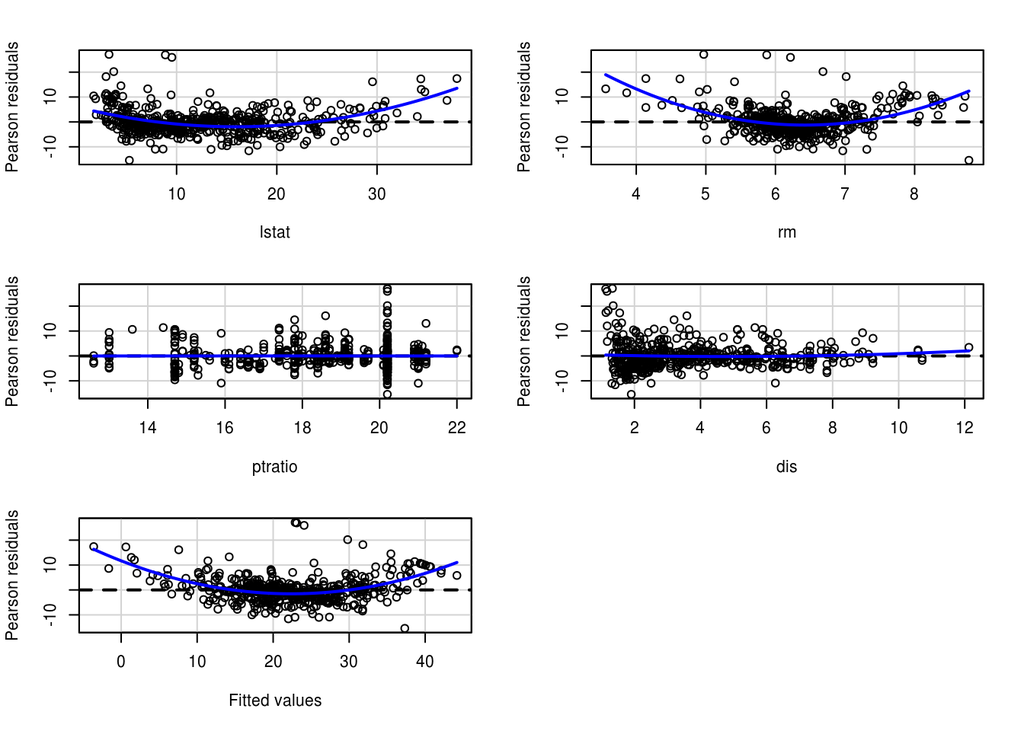

```
##            Test stat Pr(>|Test stat|)
## lstat        10.5494           <2e-16 ***
## rm           11.9955           <2e-16 ***
## ptratio      -0.0158           0.9874
## dis           1.0518           0.2934
## Tukey test   14.4890           <2e-16 ***
## ---
## Signif. codes:  0 '***' 0.001 '**' 0.01 '*' 0.05 '.' 0.1 ' ' 1
```

```r
residualPlots(mod)
```

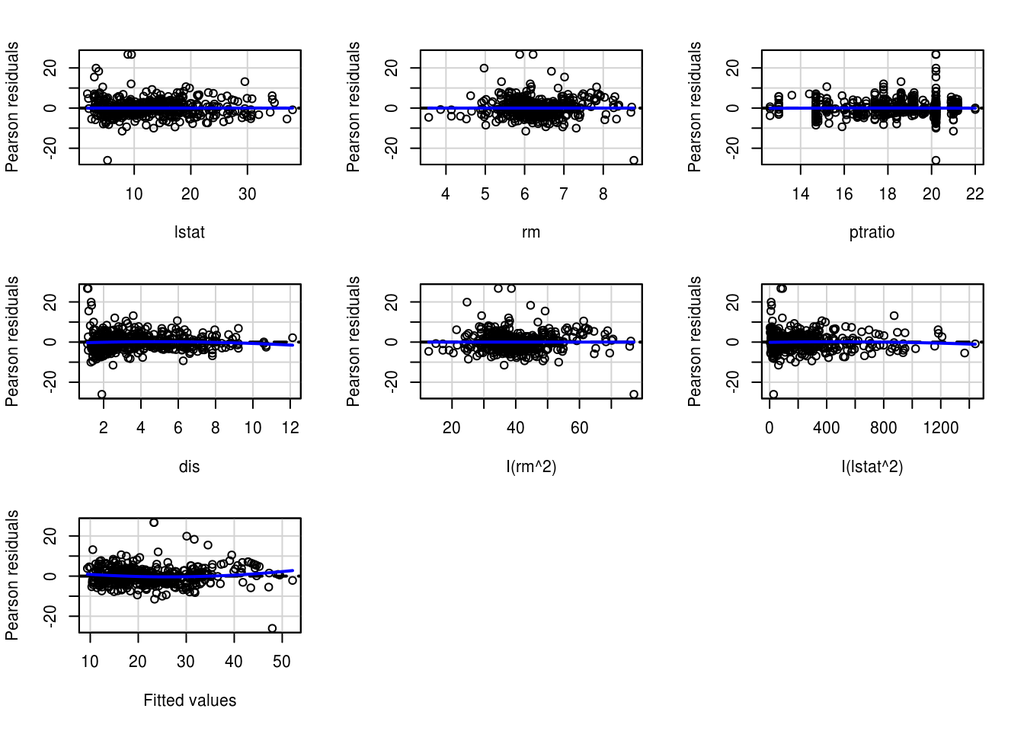

```
##            Test stat Pr(>|Test stat|)
## lstat        -0.9433           0.3460
## rm           -0.5471           0.5845
## ptratio      -0.1488           0.8818
## dis          -0.9512           0.3420
## I(rm^2)       0.0104           0.9917
## I(lstat^2)   -1.2922           0.1969
## Tukey test    3.9748        7.045e-05 ***
## ---
## Signif. codes:  0 '***' 0.001 '**' 0.01 '*' 0.05 '.' 0.1 ' ' 1
```

```r
modM <- lm(medv ~ lstat + rm + ptratio + dis + I(rm^2) + I(lstat^2), data = Boston)
residualPlots(modM)
```

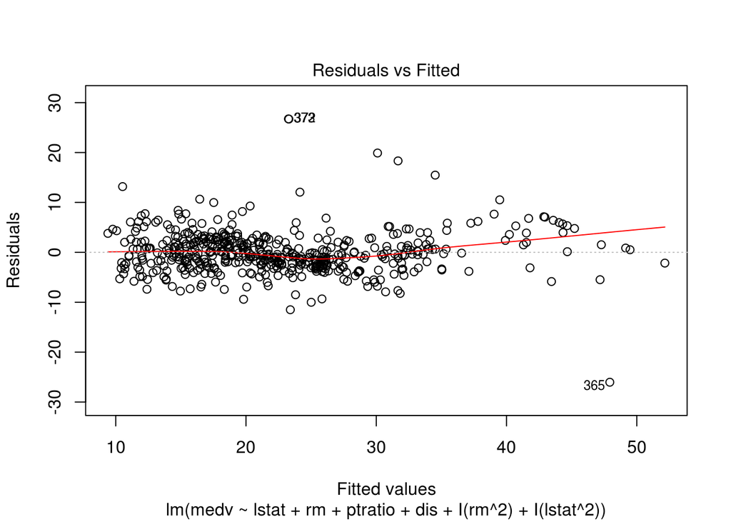

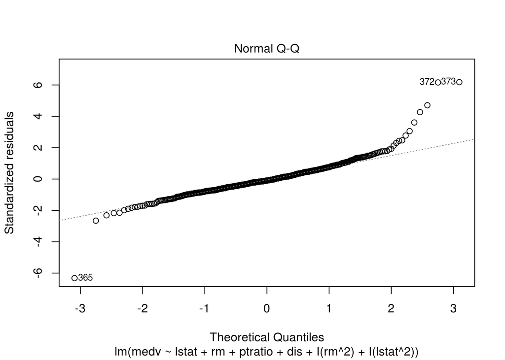

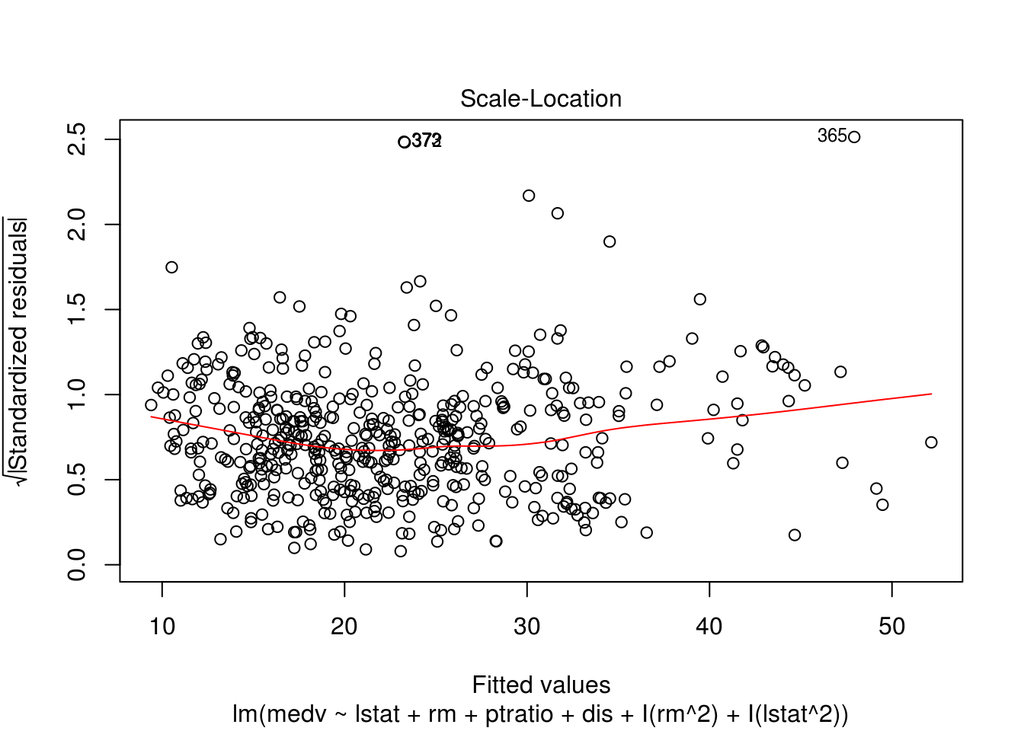

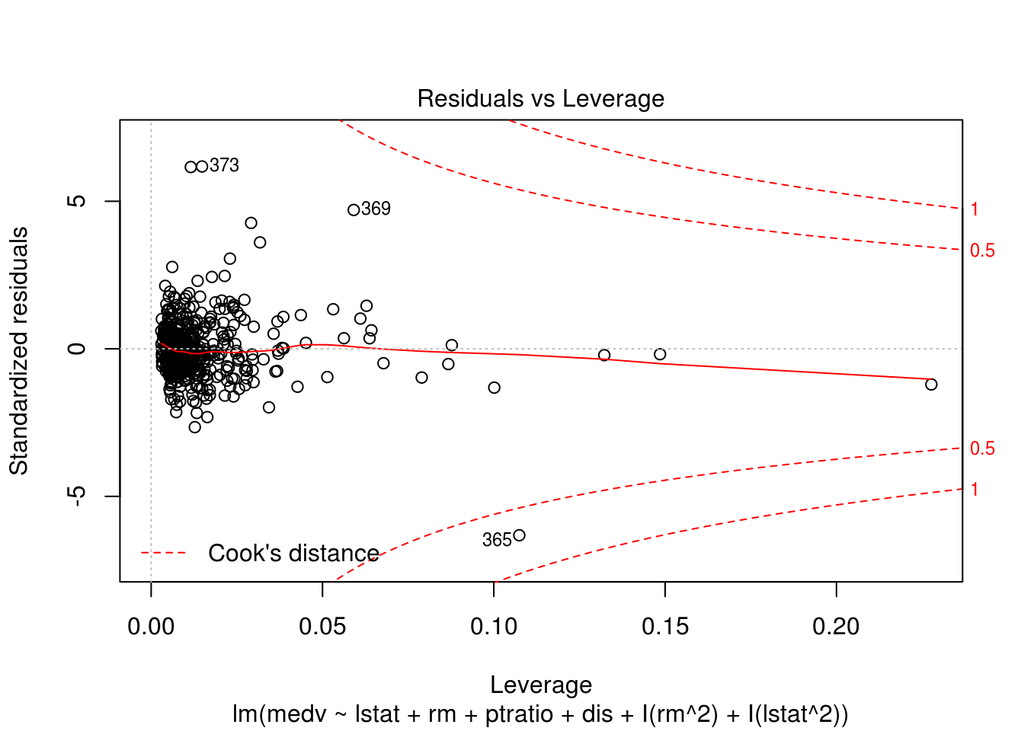

```r
plot(modM)
```

```r
summary(modM)
```

```
##
## Call:
## lm(formula = medv ~ lstat + rm + ptratio + dis + I(rm^2) + I(lstat^2),
##     data = Boston)
##
## Residuals:
##      Min       1Q   Median       3Q      Max
## -26.0300  -2.5063  -0.4023   2.0419  26.7420
##
## Coefficients:
##               Estimate Std. Error t value Pr(>|t|)
## (Intercept) 108.356403   9.542573  11.355  < 2e-16 ***
## lstat        -1.453959   0.124794 -11.651  < 2e-16 ***
## rm          -21.741421   3.027729  -7.181 2.53e-12 ***
## ptratio      -0.686263   0.100607  -6.821 2.62e-11 ***
## dis          -0.481879   0.112680  -4.277 2.28e-05 ***
## I(rm^2)       1.975818   0.235889   8.376 5.58e-16 ***
## I(lstat^2)    0.022241   0.003459   6.430 3.00e-10 ***
## ---
## Signif. codes:  0 '***' 0.001 '**' 0.01 '*' 0.05 '.' 0.1 ' ' 1
##
## Residual standard error: 4.36 on 499 degrees of freedom
## Multiple R-squared:  0.7779, Adjusted R-squared:  0.7752
## F-statistic: 291.3 on 6 and 499 DF,  p-value: < 2.2e-16
```

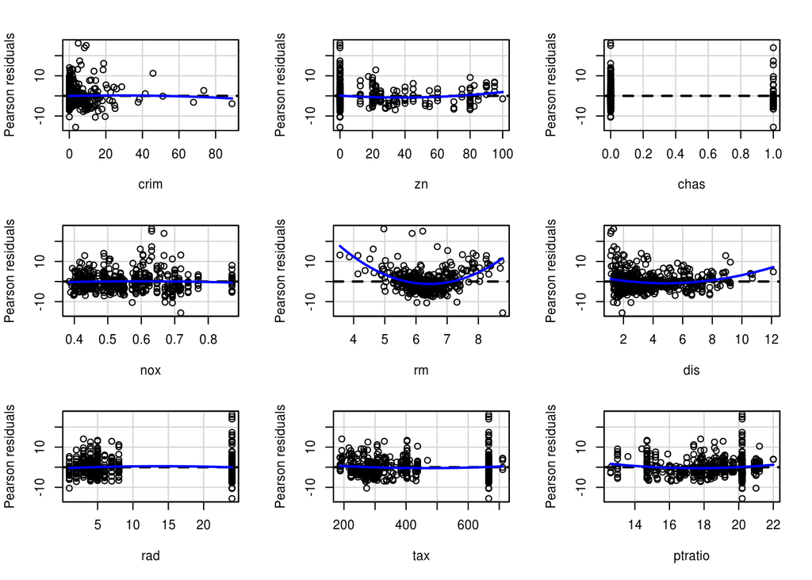

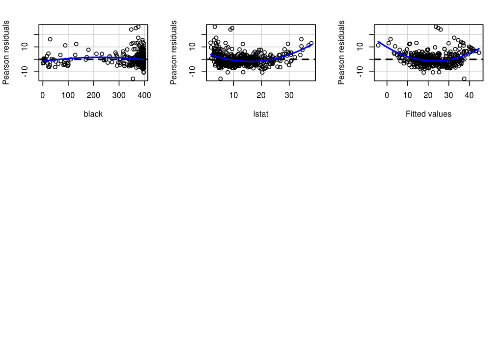

```
##            Test stat Pr(>|Test stat|)
## crim         -0.6718          0.50205
## zn            1.9920          0.04692 *
## chas          1.4513          0.14733
## nox          -0.9349          0.35027
## rm           12.4525        < 2.2e-16 ***
## dis           5.0968        4.932e-07 ***
## rad          -0.7169          0.47375
## tax           1.5488          0.12206
## ptratio       2.3511          0.01911 *
## black        -2.4446          0.01485 *
## lstat        10.3374        < 2.2e-16 ***
## Tukey test   13.6449        < 2.2e-16 ***
## ---
## Signif. codes:  0 '***' 0.001 '**' 0.01 '*' 0.05 '.' 0.1 ' ' 1
```

```r
residualPlots(mod2)
```

```r
mod3 <- update(mod2, .~. + I(lstat^2) + I(rm^2))
mod3
```

```
##
## Call:
## lm(formula = medv ~ crim + zn + chas + nox + rm + dis + rad +
##     tax + ptratio + black + lstat + I(lstat^2) + I(rm^2), data = Boston)
##
## Coefficients:
## (Intercept)         crim           zn         chas          nox
##  116.316659    -0.151178     0.020712     2.425973   -14.539960
##          rm          dis          rad          tax      ptratio
##  -21.743779    -1.164971     0.236699    -0.008668    -0.690526
##       black        lstat   I(lstat^2)      I(rm^2)
##    0.007000    -1.248991     0.020466     1.963233
```

```r
summary(mod3)
```

```
##
## Call:
## lm(formula = medv ~ crim + zn + chas + nox + rm + dis + rad +
##     tax + ptratio + black + lstat + I(lstat^2) + I(rm^2), data = Boston)
##
## Residuals:
##      Min       1Q   Median       3Q      Max
## -26.4974  -2.2978  -0.1797   1.8022  26.4403
##
## Coefficients:
##               Estimate Std. Error t value Pr(>|t|)
## (Intercept) 116.316659   9.262352  12.558  < 2e-16 ***
## crim         -0.151178   0.027816  -5.435 8.64e-08 ***
## zn            0.020712   0.011587   1.788 0.074468 .
## chas          2.425973   0.718922   3.374 0.000798 ***
## nox         -14.539960   2.995854  -4.853 1.63e-06 ***
## rm          -21.743779   2.784329  -7.809 3.49e-14 ***
## dis          -1.164971   0.158153  -7.366 7.46e-13 ***
## rad           0.236699   0.053534   4.421 1.21e-05 ***
## tax          -0.008668   0.002846  -3.046 0.002443 **
## ptratio      -0.690526   0.110027  -6.276 7.63e-10 ***
## black         0.007000   0.002255   3.104 0.002022 **
## lstat        -1.248991   0.119729 -10.432  < 2e-16 ***
## I(lstat^2)    0.020466   0.003275   6.250 8.93e-10 ***
## I(rm^2)       1.963233   0.217161   9.040  < 2e-16 ***
## ---
## Signif. codes:  0 '***' 0.001 '**' 0.01 '*' 0.05 '.' 0.1 ' ' 1
##
## Residual standard error: 3.984 on 492 degrees of freedom
## Multiple R-squared:  0.8172, Adjusted R-squared:  0.8123
## F-statistic: 169.2 on 13 and 492 DF,  p-value: < 2.2e-16
```

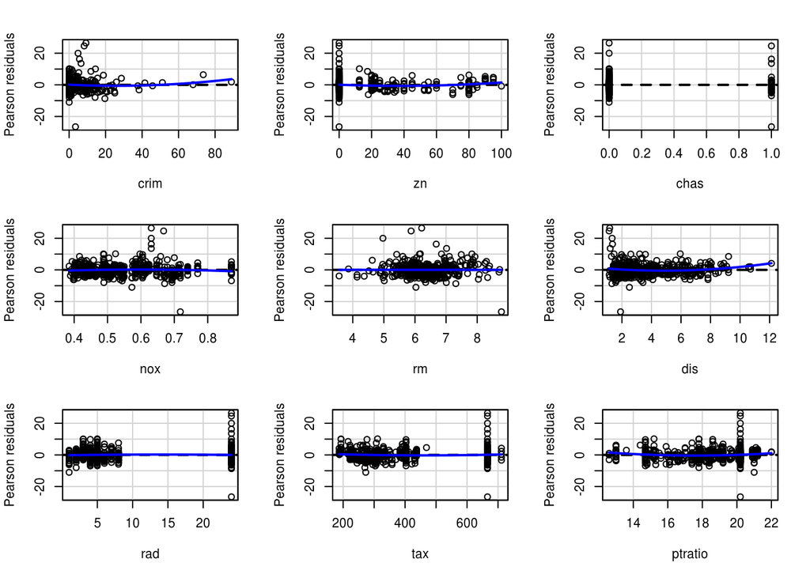

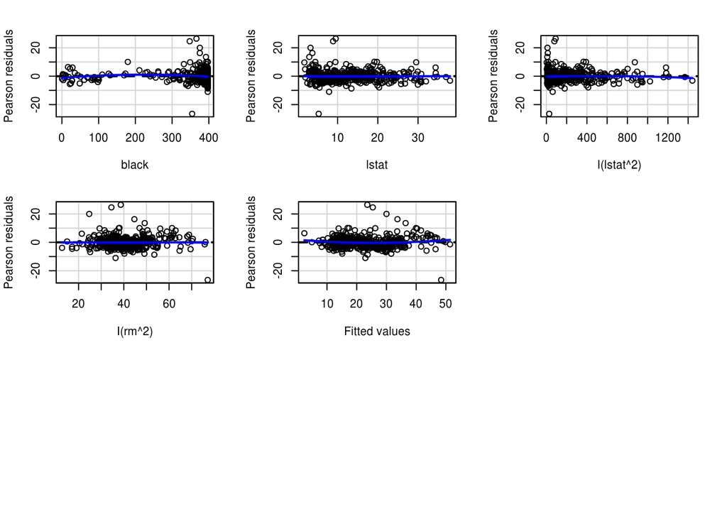

```
##            Test stat Pr(>|Test stat|)
## crim          2.3375        0.0198131 *
## zn            1.8145        0.0702118 .
## chas          0.6273        0.5307781
## nox          -1.8652        0.0627452 .
## rm            1.2221        0.2222718
## dis           3.5475        0.0004262 ***
## rad          -0.3948        0.6931794
## tax           1.2514        0.2113891
## ptratio       2.5053        0.0125564 *
## black        -1.9835        0.0478661 *
## lstat        -1.4132        0.1582339
## I(lstat^2)   -1.7890        0.0742391 .
## I(rm^2)      -0.3371        0.7362153
## Tukey test    3.2225        0.0012706 **
## ---
## Signif. codes:  0 '***' 0.001 '**' 0.01 '*' 0.05 '.' 0.1 ' ' 1
```

```r
residualPlots(mod3)
```

## Conceptual and Computational

```r
airline <- readr::read_csv("../Data/airline.csv")
airline
```

```
## # A tibble: 18 x 2
##    miles  fare
##    <dbl> <dbl>
##  1   568   219
##  2   933   222
##  3   720   249
##  4  1190   308
##  5   602   249
##  6   683   141
##  7  1719   252
##  8   589   229
##  9   327   183
## 10   894   209
## 11   419   199
## 12   749   248
## 13   749   301
## 14   392   238
## 15   657   205
## 16   461   232
## 17  1565   371
## 18  2150   343
```

- Fit a linear model by regressing `fare` onto `miles`.

```r
mod <- lm(fare ~ miles, data = airline)
summary(mod)
```

```
##
## Call:
## lm(formula = fare ~ miles, data = airline)
##
## Residuals:
##     Min      1Q  Median      3Q     Max
## -89.911 -22.881   1.304  22.978  70.747
##
## Coefficients:
##              Estimate Std. Error t value Pr(>|t|)
## (Intercept) 177.21452   19.99315   8.864 1.43e-07 ***
## miles         0.07862    0.02037   3.859  0.00139 **
## ---
## Signif. codes:  0 '***' 0.001 '**' 0.01 '*' 0.05 '.' 0.1 ' ' 1
##
## Residual standard error: 41.82 on 16 degrees of freedom
## Multiple R-squared:  0.482,  Adjusted R-squared:  0.4496
## F-statistic: 14.89 on 1 and 16 DF,  p-value: 0.00139
```

- Find $R^2$

The $R^2$ value is 0.4820137.

- What does $R^2$ mean in this context?

48.2% of the variability in airfares is explained by changes in distance.

- What is the slope of the regression line?

0.078619

- What is the $y$-intercept?

177.2145225

- What is the equation of the linear model?

$\widehat{fare} = 177.2145225 + 0.078619 \times \text{miles}$

- Estimate the fare for a 200 mile flight

```r
predict(mod, newdata = data.frame(miles = 200))
```

```
##        1
## 192.9383
```

- Estimate the fare for a 2000 mile flight

```r
predict(mod, newdata = data.frame(miles = 2000))
```

```
##        1
## 334.4526
```

- Explain what the y intercept means in this context.

The model says a flight of zero miles will cost $177.21. This could be fixed costs of air travel.

- Explain what the slope means in this context.

An increase of 1 mile means an increase of 7.86 cents.

- The fare to fly to Las Vegas, 1719 miles from Atlanta, is $252. What is the residual?

```r
yhat <- predict(mod, newdata = data.frame(miles = 1719))
yhat
```

```
##        1
## 312.3606
```

```r
(resid <- 252 - yhat)
```

```
##         1
## -60.36063
```

- In general a positive residual means…

The model has underpredicted the actual value

- In general a negative residual means…

The model has overpredicted the actual value

- Is a linear model appropriate for estimating airfare from distance flown? Why or Why not?

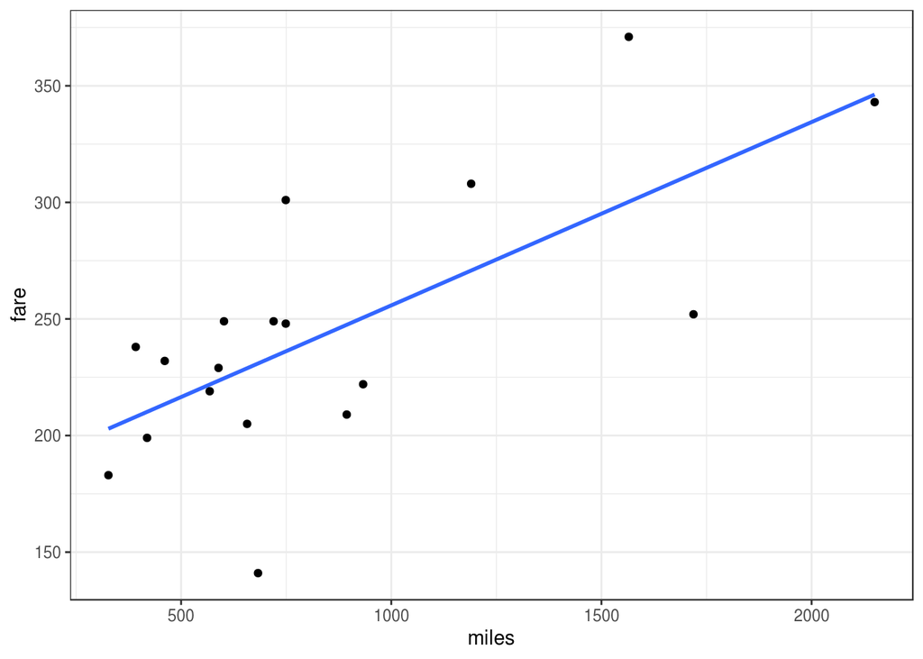

```r
library(ggplot2)
ggplot(data = airline, aes(x = miles, y = fare)) +
  geom_point() +
  theme_bw() +
  geom_smooth(se = FALSE, method = "lm")
```

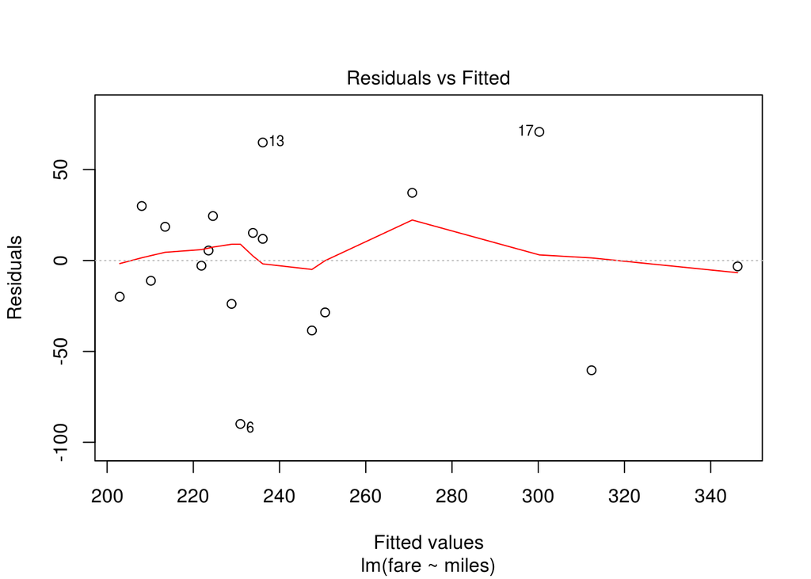

```r
plot(mod, which = 1)
```

Yes, the scatterplot shows no curve, and the residual plot has no outliers, fan shape, or curve.

- How strong is the model? Explain.

The model is moderately strong according to an $R^2$ value of 48.2%.

- Identify any outliers. Why are they unusual?

No outliers.

- If you want to predict the distance of a flight from the fare, how does the model change?

```r
mod2 <- lm(miles ~ fare, data = airline)
summary(mod2)
```

```
##
## Call:
## lm(formula = miles ~ fare, data = airline)
##
## Residuals:
##    Min     1Q Median     3Q    Max
## -452.1 -168.6 -128.8  173.3  818.3
##
## Coefficients:
##             Estimate Std. Error t value Pr(>|t|)
## (Intercept) -644.287    397.864  -1.619  0.12491
## fare           6.131      1.589   3.859  0.00139 **
## ---
## Signif. codes:  0 '***' 0.001 '**' 0.01 '*' 0.05 '.' 0.1 ' ' 1
##
## Residual standard error: 369.3 on 16 degrees of freedom
## Multiple R-squared:  0.482,  Adjusted R-squared:  0.4496
## F-statistic: 14.89 on 1 and 16 DF,  p-value: 0.00139
```

$\widehat{\text{miles}} = -644.29 + 6.131 \times \text{fare}$

Use the fare calculated for a 2000 mile flight ($334.4526) to find out how far the model above suggest you could fly.

```r
predict(mod2, newdata = data.frame(fare = 334.4526))
```

```
##        1
## 1406.244
```